# Exploratory Measurement Model Discovery with Simulated Annealing

Anthony Raborn, Psychometrician, NABP

Walter Leite, Professor, University of Florida

November 17, 2021

# Background

How can we tell the number of latent factors that explain a set of items while developing a scale?

In applied settings, the general framework is to use an Exploratory Factor Analysis (EFA) with part (e.g., half) of a data set of responses to items in order to generate hypothesis about the factor structure, then apply a Confirmatory Factor Analysis (CFA) to test these hypothesis.

This can sometimes fail as standard EFA methods do not test for *simple structures*, where each item is related to one and only one latent factor, leading to the CFA rejecting the hypothesis created based on the EFA.

# Example EFA Output

```
##
## Loadings:
##        Factor1 Factor2
## Item1   0.630   0.111
## Item2   0.558   0.031
## Item3   0.611   0.030
## Item4   0.652  -0.019
## Item5   0.595   0.042
## Item6   0.007   0.579
## Item7   0.157   0.597
## Item8   0.036   0.648
## Item9   0.039   0.581
## Item10 -0.051   0.505
##
##                Factor1 Factor2
## SS loadings      1.892   1.721
## Proportion Var   0.189   0.172
## Cumulative Var   0.189   0.361
```

# Example CFA Output

```
##
## Latent Variables:
##                    Estimate  Std.Err  z-value  P(>|z|) ci.lower ci.upper
##   F1 =~
##     Item1             0.769    0.066   11.607    0.000    0.640    0.899
##     Item2             0.697    0.069   10.080    0.000    0.561    0.832
##     Item3             0.904    0.068   13.270    0.000    0.771    1.038
##     Item4             0.765    0.068   11.243    0.000    0.632    0.899
##     Item5             0.769    0.066   11.681    0.000    0.640    0.898
##   F2 =~
##     Item6             0.810    0.066   12.287    0.000    0.681    0.940
##     Item7             0.820    0.068   12.106    0.000    0.687    0.953
##     Item8             0.977    0.071   13.819    0.000    0.839    1.116
##     Item9             0.751    0.070   10.757    0.000    0.614    0.888
##     Item10            0.730    0.062   11.841    0.000    0.609    0.851
##
## Covariances:
##                    Estimate  Std.Err  z-value  P(>|z|) ci.lower ci.upper
##   F1 ~~
##     F2                0.223    0.063    3.521    0.000    0.099    0.347
##
## Variances:
##                    Estimate  Std.Err  z-value  P(>|z|) ci.lower ci.upper
##    .Item1             0.996    0.088   11.337    0.000    0.824    1.168
##    .Item2             1.181    0.097   12.219    0.000    0.991    1.370
##    .Item3             0.918    0.092    9.922    0.000    0.736    1.099
##    .Item4             1.075    0.093   11.576    0.000    0.893    1.257
##    .Item5             0.978    0.087   11.286    0.000    0.808    1.148
##    .Item6             0.985    0.087   11.260    0.000    0.813    1.156
##    .Item7             1.052    0.092   11.381    0.000    0.871    1.233
##    .Item8             1.000    0.100   10.000    0.000    0.804    1.196
##    .Item9             1.207    0.099   12.138    0.000    1.012    1.401
##    .Item10            0.886    0.077   11.548    0.000    0.736    1.036
##     F1                1.000                               1.000    1.000
##     F2                1.000                               1.000    1.000
```

# Metaheuristic Algorithms

Related problems in factor analysis and structural equation modeling include model specification searches models[^1], item selection for CFA[^2], and sensitivity analysis for structural equation models[^3].

Metaheuristic algorithms have been successfully used to provide solutions to these problems, but require a starting model be specified in advance before the algorithms search for a solution.

# The Simulated Annealing Algorithm

The simulated annealing (SA) algorithm mimics the physical annealing of metals[^4]. It searches for the global optimum of a problem space and has been used for a variety of optimization problems; prior research has shown it to be particularly useful for finding short forms of scales that meet fit statistic requirements[^5].

The algorithm requires an optimization function, a temperature function, and selection function that uses the first two to determine the probability of accepting proposed solutions at each iteration.

# Hill Climbing with Simulated Annealing

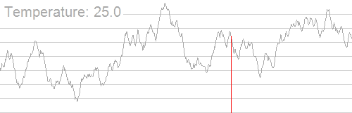

[^6]

# Objective

To propose and evaluate a method for exploratory measurement model discovery that combines the simulated annealing (SA) algorithm with CFA models.

# Algorithm Flowchart

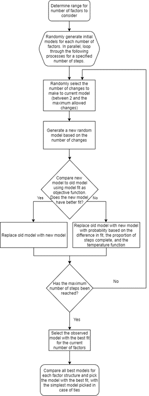

# Temperature Function

$$T = \left(\frac{maxSteps - currentStep}{maxSteps}\right)^7$$

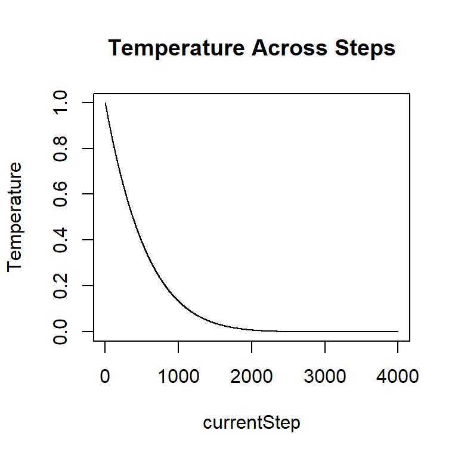

# Selection Function

$${\scriptstyle \begin{equation} P(Model_{New}|Fit_{New},Fit_{Old},T) = \\
\begin{cases} \exp\biggl(\, \frac{Fit_{New} - Fit_{Old}}{T}\biggr), & Fit_{New} \leq Fit_{Old} \\ 1, & Fit_{New} > Fit_{Old} \end{cases} \end{equation} }$$

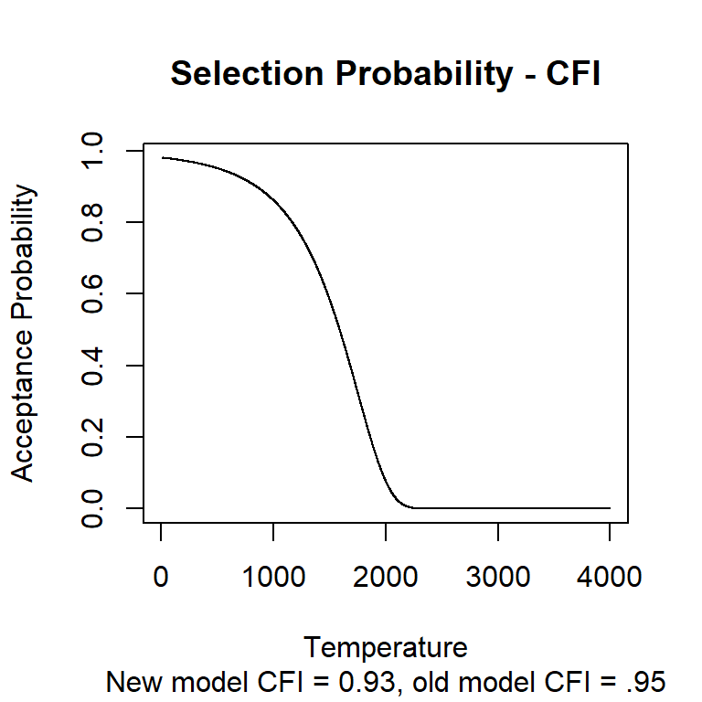

# Method

Population models:

- Simulated in R with `lavaan` v0.6-7[^7]
- Two-factor model with 10, 30, and 60 items
- 20 and 80 observations per item
- Factors correlated at 0.3 and 0.7
- Factor loadings $\lambda_i$ generated from median values 0.4, 0.6, and 0.8
  - Drawn from range of $\pm 0.1$ around median
  - Measurement error was $1 - \lambda_i$
- 36 models (3 items x 2 observations x 2 correlations x 3 factor loading conditions)
- 100 population models (iterations)
- 3600 total models

We set the maximum number of steps of the algorithm to 4000, used the temperature function presented earlier, and used standard values for other tuning parameters of the SA algorithm (e.g., the Kirkpatrick goal function).

Average run time per analysis condition ranged from just under 10 minutes to just over 100 minutes.

# Results: Correct Number of Latent Factors

# 5 Items Per Factor

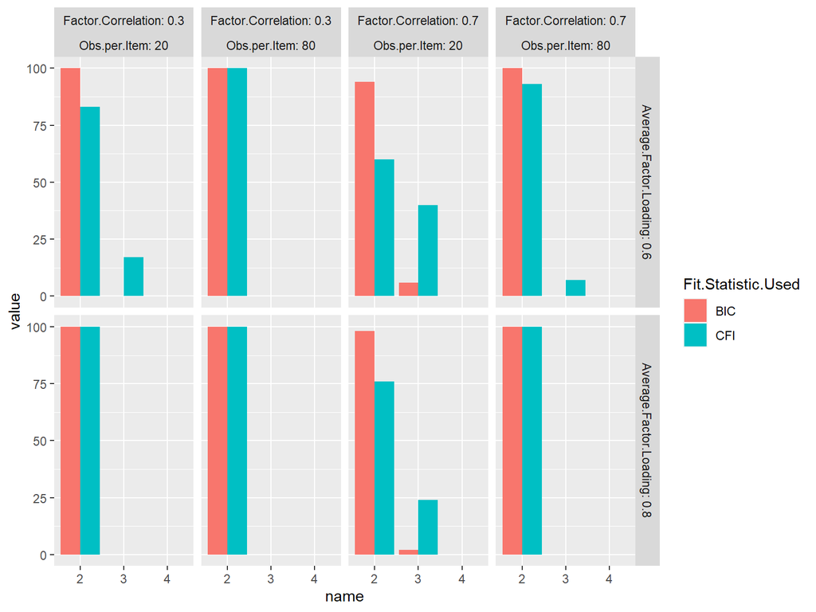

# 15 Items Per Factor

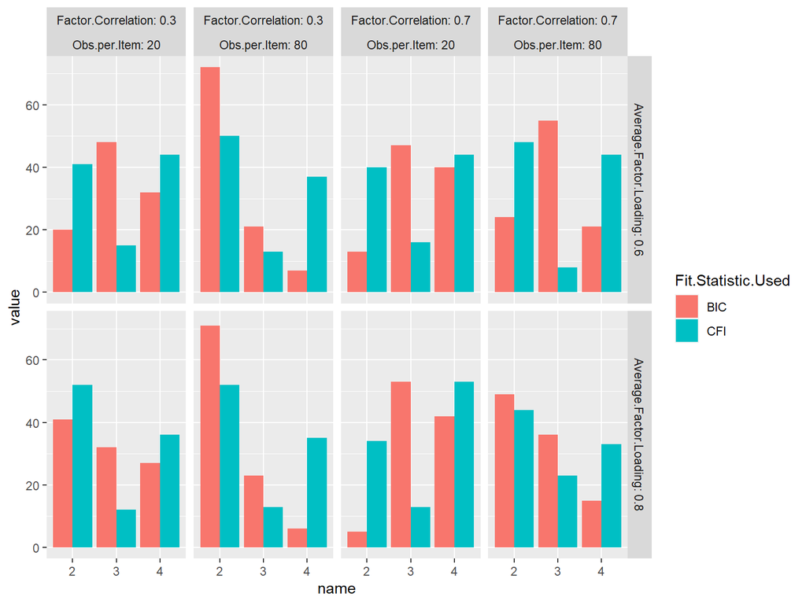

# 30 Items Per Factor

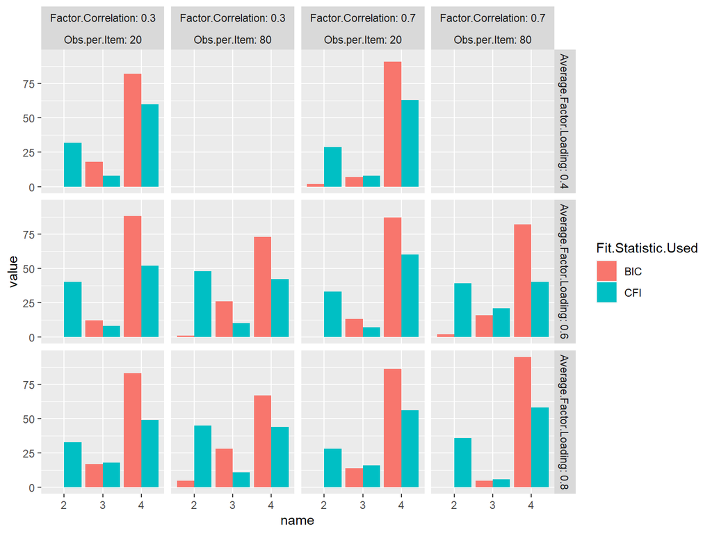

- With 5 items per factor, BIC recovers the number of latent factors almost every time
  - CFI tends to do worse with fewer observations per item
- As the number of items increases, both BIC and CFI tend to find more latent factors
  - BIC is more affected by this than CFI
- As the average factor loading decreases, the accuracy decreases
- As the factor correlation increases, the accuracy decreases
- Overall, CFI is more accurate
  - Appears due to CFI having similar levels of accuracy across most conditions
  - BIC has more conditions with very high accuracy but more conditions with very low accuracy

# Results: Proper Model Specification

# 5 Items Per Factor

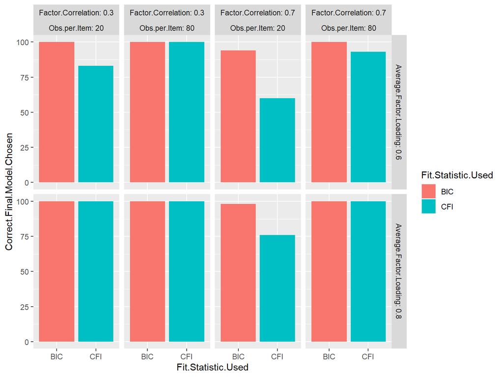

# 15 Items Per Factor

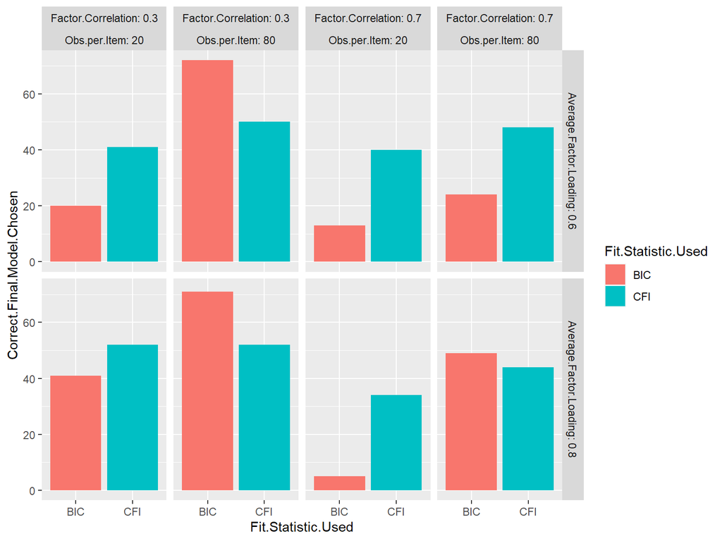

# 30 Items Per Factor

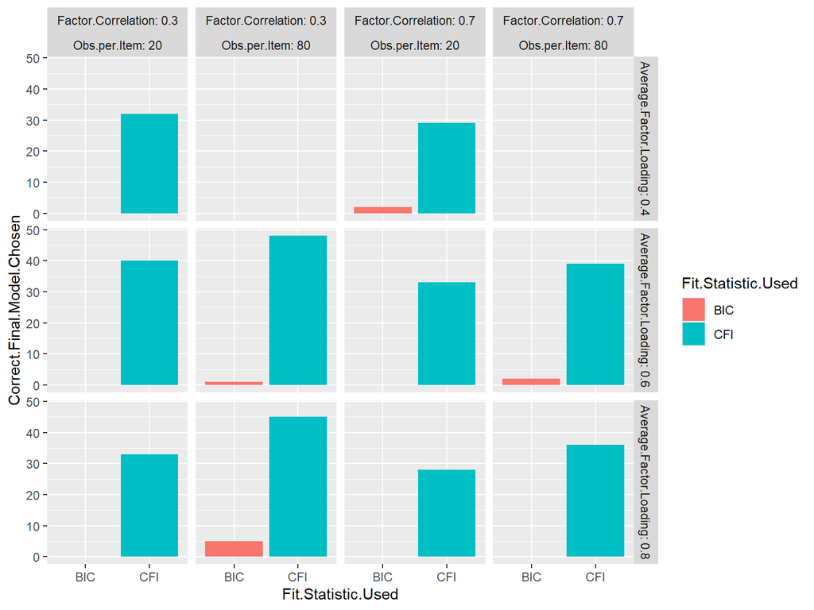

- Similar results for model specification:
  - CFI more accurate *overall* due to high accuracy in many of conditions and moderate accuracy in all others
  - BIC has more conditions with high accuracy than CFI, but far worse accuracy in all others
  - Especially noticeable as items per factor increases
- As items and factor correlations increase model specification accuracy decreases
- As average factor loadings and number of observations decrease model specification accuracy decreases

# Conclusion

This algorithm shows some utility for combining exploratory and confirmatory factor analysis methods under certain conditions so far. Particularly, when there are only a few items in the item pool (e.g., at least 10 but less than 30), the algorithm using BIC as the objective function can reproduce the data generating model even with as few as 20 observations per item.

Further research is needed to see if these results extend to population models with more latent factors, if tuning the model parameters (e.g., letting the algorithm run for a longer period of time or adjusting the temperature function) improves the accuracy of the algorithm, and if other objective functions might have better accuracy in other conditions.

# Questions

If you have any questions after the presentation, please email the first author at anthony.w.raborn@gmail.com

A copy of this presentation is available at https://github.com/AnthonyRaborn/conference-presentations

# Thank you!

[^1]: Marcoulides & Drezner, 2003; Marcoulides et al., 1998; Marcoulides & Falk, 2018
[^2]: Leite et al., 2008; Raborn & Leite, 2018; Raborn et al., 2020
[^3]: Leite et al., 2021.
[^4]: Cerny, 1985; Kirkpatrick et al., 1983
[^5]: Raborn et al., 2020
[^6]: Kingpin13, CC0, via Wikimedia Commons
[^7]: Rosseel, 2017